# Modeling and prediction for movies

## Setup

### Loading packages and Data

```r
library(ggplot2)
library(dplyr)
library(statsr)
library(GGally)
library("gplots")
library(gridExtra)
library(grid)
library(plotmo)
```

```r
load("movies.Rdata")
```

## Part 1: Data

The data set **is a random sample** of size 651 produced and released before 2016, thus we can generalize our conclusions for movies from that range. The movies may have different scores from each system, since users with different preferences may prefer to use one system or the other. Given that users **voluntarely** rate the movies, we should not consider our conclusions as the World preference. Instead, we should state something similar to “according to users who rated movies produced and released before 2016 from the rating systems Rotten Tomatoes and IMDB…”. Also, we should not state anything about users, since we do not garantee that the users who voted for these movies could be considered a sample that represents the population; that is, users that voted for these movies do not represent a random sample of all users. All these could represent **bias** or errors/mistakes in our analysis, depending on how and for what we are using the data. **No random assignment** was used, thus it is suitable for **observational studies**.

In this **observational study**, we will focus only on the ratings from **Roten Tomatoes**. The reason is that doing so we are controlling the possible **bias caused by users that rated a movie in both systems**.

## Part 2: Research question

The main charachteristic of the Rotten Tomatoes system is that for many movies the *audience* and *critics* rates can be very different. Identifying the variables that can be associated to the differences could help us understand and define future experiments to try to create movies that both groups would love.

Given the differences between both scores, we define our **resesarch question** as follows:

> Is there an overwall difference between audicence and critics’ opinions? Could the differences that happens in each movie be predicted by variables related to Genre, Director, Best Picture and best Actor/Actress Oscars?

The critics score is defined as the percentage of critics that gave a positive review. The audience score is the percentage of users that rated it as 3.5 to 5 stars.

## Part 3: Exploratory data analysis

We first explore the two variables that will be used to create the response variable: **critics_score** and **audience_score**:

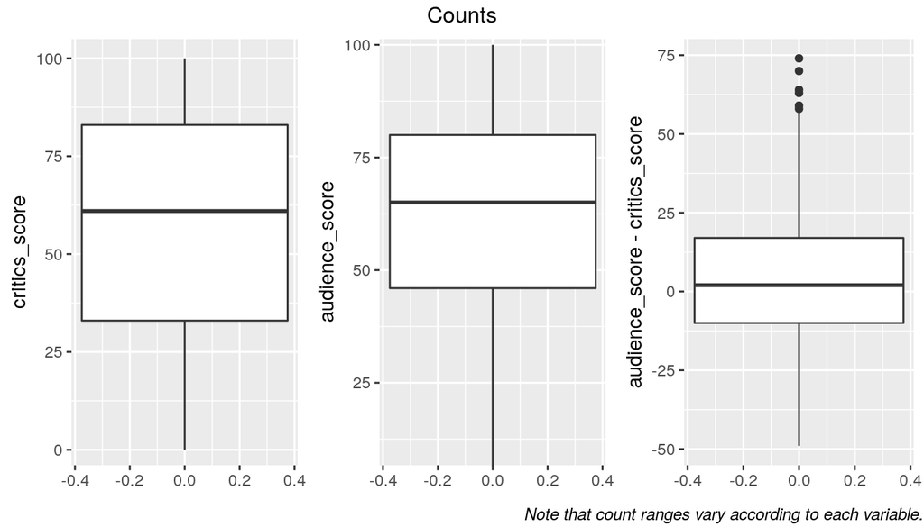

```r
# plotting variables as horizontal -> Labels are read horizontally
p1 <- ggplot(aes(y=critics_score), data=movies) + geom_boxplot(ymin=0, ymax=100)
p2 <- ggplot(aes(y=audience_score), data=movies) + geom_boxplot(ymin=0, ymax=100)
p3 <- ggplot(aes(y=audience_score-critics_score), data=movies) + geom_boxplot()

# Create a grid of plots
grid.arrange(
  p1,  p2, p3,
  nrow = 1,
  top = "Counts",
  bottom = textGrob(
    "Note that count ranges vary according to each variable.",
    gp = gpar(fontface = 3, fontsize = 9),
    hjust = 1,
    x = 1
  )
)
```

```r
summary(movies$critics_score)
```

```
##    Min. 1st Qu.  Median    Mean 3rd Qu.    Max.
##    1.00   33.00   61.00   57.69   83.00  100.00
```

```r
summary(movies$audience_score)
```

```
##    Min. 1st Qu.  Median    Mean 3rd Qu.    Max.
##   11.00   46.00   65.00   62.36   80.00   97.00
```

With the boxplots, we can see that both critical and audience scores have a similar overall value, with the audience mean and median score greater than the critics score (two first boxplots). The third boxplot presents the **paired** difference. Since we are going to build linear models later, we choose to create a new variable with the paired difference, defined by:

```r
movies <- movies %>% mutate(score_diff = audience_score-critics_score)
```

Now, we want to make sure that the difference in fact exist to proceed to the Linear Regression analysis. So, we will perform a statistical test to check the hypotheses:

$H_0: \mu_{score\_diff} = 0$

$H_A: \mu_{score\_diff} \neq 0$

Since the observations for the difference are independent, the samples are random and we have a great sample size, we test if there is an average difference and what is the 95% confidence interval:

```r
# Hypotheses test
inference(y = score_diff, data=movies, type = "ht", statistic = "mean", alternative = "twosided", method = "theoretical", null = 0)
```

```
## Single numerical variable
## n = 651, y-bar = 4.6743, s = 20.1652
## H0: mu = 0
## HA: mu != 0
## t = 5.9144, df = 650
## p_value = < 0.0001
```

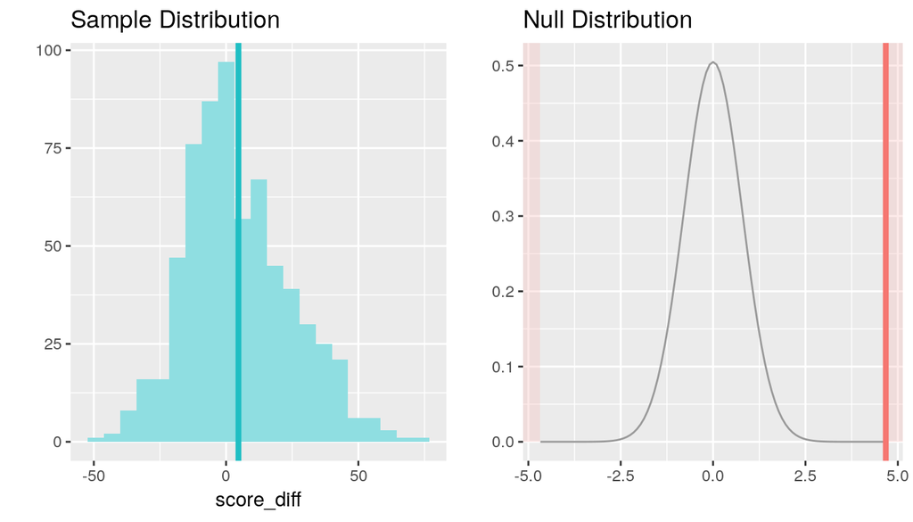

```r
# CI
inference(y = score_diff, data=movies, type = "ci", statistic = "mean", alternative = "twosided", method = "theoretical", null = 0, conf_level = 0.95)
```

```
## Single numerical variable
## n = 651, y-bar = 4.6743, s = 20.1652
## 95% CI: (3.1224 , 6.2263)
```

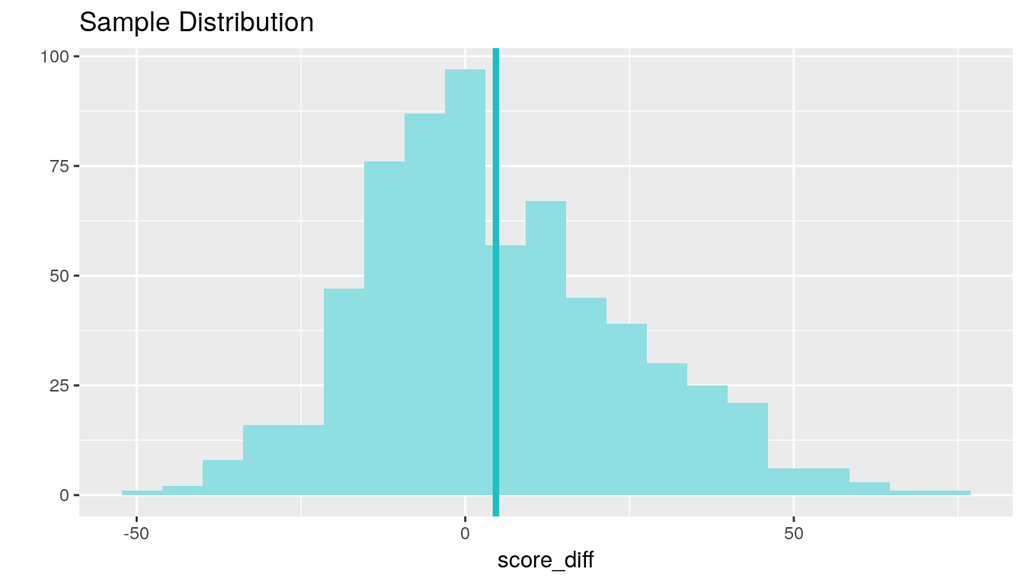

By the results above, we are 95% confident that on average the audience score is 3.12 to 6.22 points greater than the critics score. Despite the difference exist and is statistically significant (p < 0.001), it is not too big, considering that the points cand go from 0 to 100. Also, we would expect that the bigger differences occurs only for a few number of movies, since critics usually score, for instance, cult movies with great scores and the general audience would be less interested on these. This is indeed a pattern that we could check in **future work**, once we can see in the histogram of score_diff that for many movies the differences can have absolute value greater than 20 points.

Having checked that in fact there are many movies with great differences and that on average the audience and critics also rate then differently, we are going to create an overview of some movies’ variables in association with the **score_diff**.

The first variable is **genre**

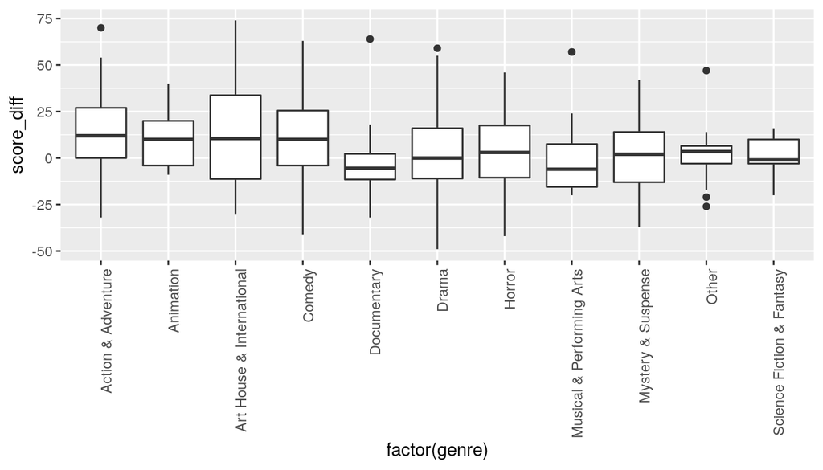

```r
ggplot(data=movies, mapping = aes(x=factor(genre),y=score_diff)) + geom_boxplot() + theme(axis.text.x=element_text(angle=90, hjust=1))
```

As we can see, “Documentary” and “Musical & Performing Arts” movies have medians bellow 0, indicating critics have some preference on these categores. On the other hand, it is clear that “Action & Adventure” is prefered by the general audience, once 75% of the differences are positive (audience-critics).

The next are **best_pic_nom**, **best_pic_win** and **best_actor_or_actress_win**. The latter is created by the OR operation between variables **best_actress_win** and **best_actor_win**.

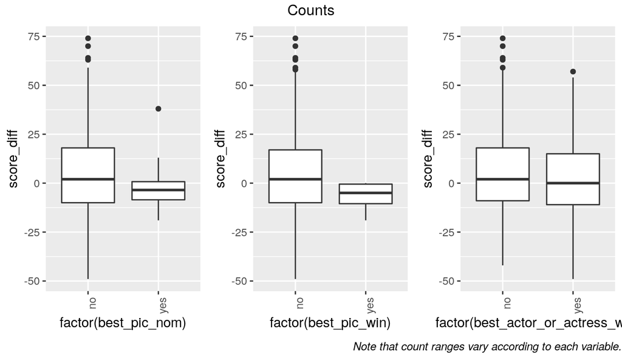

```r
movies <- movies %>%
  mutate(best_actor_or_actress_win = ifelse(best_actress_win=="yes" | best_actor_win=="yes", "yes", "no"))

p1 <- ggplot(data=movies, mapping = aes(x=factor(best_pic_nom),y=score_diff)) + geom_boxplot() + theme(axis.text.x=element_text(angle=90, hjust=1))
p2 <- ggplot(data=movies, mapping = aes(x=factor(best_pic_win),y=score_diff)) + geom_boxplot() + theme(axis.text.x=element_text(angle=90, hjust=1))
p3 <- ggplot(data=movies, mapping = aes(x=factor(best_actor_or_actress_win),y=score_diff)) + geom_boxplot() + theme(axis.text.x=element_text(angle=90, hjust=1))

grid.arrange(
  p1,  p2, p3,
  nrow = 1,
  top = "Counts",
  bottom = textGrob(
    "Note that count ranges vary according to each variable.",
    gp = gpar(fontface = 3, fontsize = 9),
    hjust = 1,
    x = 1
  )
)
```

According to the boxplots, it seems that the variables related to Best Picture and best Actor/Actress could be considered to test in the model building/selecting process.

The variable **director** has many categorical values, thus will only be considered in the following analysis.

## Part 4: Modeling

In this section we explore the Linear Regression method to analyse the association between the explanatory variables **best_pic_nom**, **best_pic_win**, **best_actor_or_actress_win**, **genre** and the response variable **score_diff**.

We first consider all models and check the slopes, adjusted $R^2$ and statistical significance:

```r
m1 <- lm(score_diff ~ best_pic_nom + best_pic_win + best_actor_or_actress_win + genre + director, data = movies)
s <- summary(m1)
s$r.squared
```

```
## [1] 0.9090159
```

```r
s$adj.r.squared
```

```
## [1] 0.4330988
```

When we remove **director** we have a great decrease in the adjusted $R^2$, from 0.43 to 0.04.

```r
m2 <- lm(score_diff ~ best_pic_nom + best_pic_win + best_actor_or_actress_win + genre, data = movies)
s2 <- summary(m2)
s2$r.squared
```

```
## [1] 0.06053853
```

```r
s2$adj.r.squared
```

```
## [1] 0.04136584
```

**Despite it may look that director is a good variable, it is not**. Most of movies have different directors and, by consequence, using this variable would create a predictor extremely overfitted. For instance, by the following code we check that only 5 directors appear in more than 3 movies (they appear in exactly 4 movies). Thus, **we remove the variable director** from the model.

```r
summary(table(factor(movies$director))>3)
```

```
##    Mode   FALSE    TRUE
## logical     527       5
```

Here, then, we define our initial full model, formed by est_pic_nom, best_pic_win, best_actor_or_actress_win and genre:

```r
summary(m2)
```

```
##
## Call:
## lm(formula = score_diff ~ best_pic_nom + best_pic_win + best_actor_or_actress_win +
##     genre, data = movies)
##
## Residuals:
##     Min      1Q  Median      3Q     Max
## -52.901 -14.191  -2.485  12.519  67.528
##
## Coefficients:
##                                  Estimate Std. Error t value Pr(>|t|)
## (Intercept)                     12.481256   2.457983   5.078 5.02e-07 ***
## best_pic_nomyes                 -3.065783   4.982225  -0.615  0.53855
## best_pic_winyes                 -7.736649   8.551622  -0.905  0.36597
## best_actor_or_actress_winyes    -1.183090   1.959570  -0.604  0.54622
## genreAnimation                   0.003875   7.025684   0.001  0.99956
## genreArt House & International  -0.039607   5.817739  -0.007  0.99457
## genreComedy                     -0.580501   3.239445  -0.179  0.85784
## genreDocumentary               -16.009155   3.674667  -4.357 1.54e-05 ***
## genreDrama                      -8.702689   2.727992  -3.190  0.00149 **
## genreHorror                    -10.611691   4.794803  -2.213  0.02724 *
## genreMusical & Performing Arts  -8.882665   6.203545  -1.432  0.15267
## genreMystery & Suspense        -10.808152   3.583209  -3.016  0.00266 **
## genreOther                      -9.915817   5.553052  -1.786  0.07463 .
## genreScience Fiction & Fantasy -11.592367   7.025269  -1.650  0.09942 .
## ---
## Signif. codes:  0 '***' 0.001 '**' 0.01 '*' 0.05 '.' 0.1 ' ' 1
##
## Residual standard error: 19.74 on 637 degrees of freedom
## Multiple R-squared:  0.06054,    Adjusted R-squared:  0.04137
## F-statistic: 3.158 on 13 and 637 DF,  p-value: 0.0001322
```

From preliminary experiments and by models m1 and m2, we found that the $R^2$ and adjusted $R^2$ were very low and we could not increase it. Thus, the models do not have good prediction accuracy. **For this reason, we limit here our analysis to understanding which variables are statistically significant predictors of the response**. Hence, we will use here a Backward elimination strategy based on **p-values**.

Given our initial model m2, we now remove the variable/slope with highest p-value, which would be **best_pic_nom**. The new model is m3:

```r
m3 <- lm(score_diff ~ best_pic_win + best_actor_or_actress_win + genre, data = movies)
summary(m3)
```

```
##
## Call:
## lm(formula = score_diff ~ best_pic_win + best_actor_or_actress_win +
##     genre, data = movies)
##
## Residuals:
##     Min      1Q  Median      3Q     Max
## -52.922 -14.211  -2.482  12.579  67.518
##
## Coefficients:
##                                 Estimate Std. Error t value Pr(>|t|)
## (Intercept)                     12.50024    2.45659   5.088 4.75e-07 ***
## best_pic_winyes                -10.18581    7.56524  -1.346  0.17865
## best_actor_or_actress_winyes    -1.35940    1.93756  -0.702  0.48318
## genreAnimation                   0.02407    7.02219   0.003  0.99727
## genreArt House & International  -0.04600    5.81490  -0.008  0.99369
## genreComedy                     -0.57820    3.23787  -0.179  0.85833
## genreDocumentary               -16.01797    3.67285  -4.361 1.51e-05 ***
## genreDrama                      -8.79980    2.72210  -3.233  0.00129 **
## genreHorror                    -10.63068    4.79237  -2.218  0.02689 *
## genreMusical & Performing Arts  -8.88696    6.20052  -1.433  0.15227
## genreMystery & Suspense        -10.82680    3.58134  -3.023  0.00260 **
## genreOther                     -10.26293    5.52164  -1.859  0.06353 .
## genreScience Fiction & Fantasy -11.61135    7.02178  -1.654  0.09870 .
## ---
## Signif. codes:  0 '***' 0.001 '**' 0.01 '*' 0.05 '.' 0.1 ' ' 1
##
## Residual standard error: 19.73 on 638 degrees of freedom
## Multiple R-squared:  0.05998,    Adjusted R-squared:  0.0423
## F-statistic: 3.392 on 12 and 638 DF,  p-value: 7.851e-05
```

The p-value decreased. Now the highest p-value is from **best_actor_or_actress_win**, thus model m4 will be:

```r
m4 <- lm(score_diff ~ best_pic_win  + genre, data = movies)
summary(m4)
```

```
##
## Call:
## lm(formula = score_diff ~ best_pic_win + genre, data = movies)
##
## Residuals:
##     Min      1Q  Median      3Q     Max
## -52.710 -14.305  -2.305  12.695  67.596
##
## Coefficients:
##                                  Estimate Std. Error t value Pr(>|t|)
## (Intercept)                     12.353846   2.446742   5.049 5.80e-07 ***
## best_pic_winyes                -10.776041   7.515331  -1.434 0.152097
## genreAnimation                  -0.131624   7.015889  -0.019 0.985038
## genreArt House & International   0.003297   5.812161   0.001 0.999548
## genreComedy                     -0.643777   3.235230  -0.199 0.842334
## genreDocumentary               -15.950000   3.670113  -4.346 1.61e-05 ***
## genreDrama                      -9.049321   2.697692  -3.354 0.000842 ***
## genreHorror                    -10.484281   4.785921  -2.191 0.028838 *
## genreMusical & Performing Arts  -8.853846   6.197876  -1.429 0.153628
## genreMystery & Suspense        -11.154252   3.549383  -3.143 0.001752 **
## genreOther                     -10.541346   5.505169  -1.915 0.055963 .
## genreScience Fiction & Fantasy -11.464957   7.015889  -1.634 0.102722
## ---
## Signif. codes:  0 '***' 0.001 '**' 0.01 '*' 0.05 '.' 0.1 ' ' 1
##
## Residual standard error: 19.73 on 639 degrees of freedom
## Multiple R-squared:  0.05925,    Adjusted R-squared:  0.04306
## F-statistic: 3.659 on 11 and 639 DF,  p-value: 4.701e-05
```

The p-value reduced again, and now the highest p-value is from **best_pic_win**:

```r
m5 <- lm(score_diff ~  genre, data = movies)
summary(m5)
```

```
##
## Call:
## lm(formula = score_diff ~ genre, data = movies)
##
## Residuals:
##     Min      1Q  Median      3Q     Max
## -52.586 -14.128  -2.354  12.872  67.596
##
## Coefficients:
##                                  Estimate Std. Error t value Pr(>|t|)
## (Intercept)                     12.353846   2.448759   5.045 5.92e-07 ***
## genreAnimation                  -0.131624   7.021675  -0.019 0.985050
## genreArt House & International   0.003297   5.816954   0.001 0.999548
## genreComedy                     -0.767639   3.236744  -0.237 0.812605
## genreDocumentary               -15.950000   3.673139  -4.342 1.64e-05 ***
## genreDrama                      -9.225977   2.697100  -3.421 0.000664 ***
## genreHorror                    -10.484281   4.789868  -2.189 0.028969 *
## genreMusical & Performing Arts  -8.853846   6.202987  -1.427 0.153966
## genreMystery & Suspense        -11.336897   3.550021  -3.193 0.001475 **
## genreOther                     -10.541346   5.509709  -1.913 0.056164 .
## genreScience Fiction & Fantasy -11.464957   7.021675  -1.633 0.103004
## ---
## Signif. codes:  0 '***' 0.001 '**' 0.01 '*' 0.05 '.' 0.1 ' ' 1
##
## Residual standard error: 19.74 on 640 degrees of freedom
## Multiple R-squared:  0.05623,    Adjusted R-squared:  0.04148
## F-statistic: 3.813 on 10 and 640 DF,  p-value: 5.087e-05
```

Here, using **genre** alone, the model fit p-value increased in comparison to when we used **genre** and **best_pic_win**. Thus, considering the p-value approach, **we chose model m4**, with explanatory variables **genre** and **best_pic_win**:

```r
summary(m4)
```

```
##
## Call:
## lm(formula = score_diff ~ best_pic_win + genre, data = movies)
##
## Residuals:
##     Min      1Q  Median      3Q     Max
## -52.710 -14.305  -2.305  12.695  67.596
##
## Coefficients:
##                                  Estimate Std. Error t value Pr(>|t|)
## (Intercept)                     12.353846   2.446742   5.049 5.80e-07 ***
## best_pic_winyes                -10.776041   7.515331  -1.434 0.152097
## genreAnimation                  -0.131624   7.015889  -0.019 0.985038
## genreArt House & International   0.003297   5.812161   0.001 0.999548
## genreComedy                     -0.643777   3.235230  -0.199 0.842334
## genreDocumentary               -15.950000   3.670113  -4.346 1.61e-05 ***
## genreDrama                      -9.049321   2.697692  -3.354 0.000842 ***
## genreHorror                    -10.484281   4.785921  -2.191 0.028838 *
## genreMusical & Performing Arts  -8.853846   6.197876  -1.429 0.153628
## genreMystery & Suspense        -11.154252   3.549383  -3.143 0.001752 **
## genreOther                     -10.541346   5.505169  -1.915 0.055963 .
## genreScience Fiction & Fantasy -11.464957   7.015889  -1.634 0.102722
## ---
## Signif. codes:  0 '***' 0.001 '**' 0.01 '*' 0.05 '.' 0.1 ' ' 1
##
## Residual standard error: 19.73 on 639 degrees of freedom
## Multiple R-squared:  0.05925,    Adjusted R-squared:  0.04306
## F-statistic: 3.659 on 11 and 639 DF,  p-value: 4.701e-05
```

With this model, we expect the value of differences be lower (**slope** -10.77, on average) for movies with a Best Picture Oscar, with all others constant. The **intercept** represents the movies with no Best Picture Oscar and that are in the category “Action & Adventure”. Since this represents the most positive value, the intercept also represents (here) the group of movies where we find most of the time a positive difference. We can see that in the boxplots from section Part 3, that shows the both Q2 and Q3 above 0, indicating that the audience usually rate this genre of movies with as good more than the critics. All other **slopes** are negative, except “genreArt House & International”. Their slope values make the differences be around zero; that is, when a value 1 is set to one of the variables, the slope is summed with the Intercept.

### Diagnostics

#### Linearity of explanatory variables

Since the **genre** and **best_pic_win** are transformed into many **dummy** variables, they met the condition of linearity by definition: they represent 2 points, which represent a line.

#### Nearly normal residuals

The residuals are nearly normal, what can be checked by the following plot:

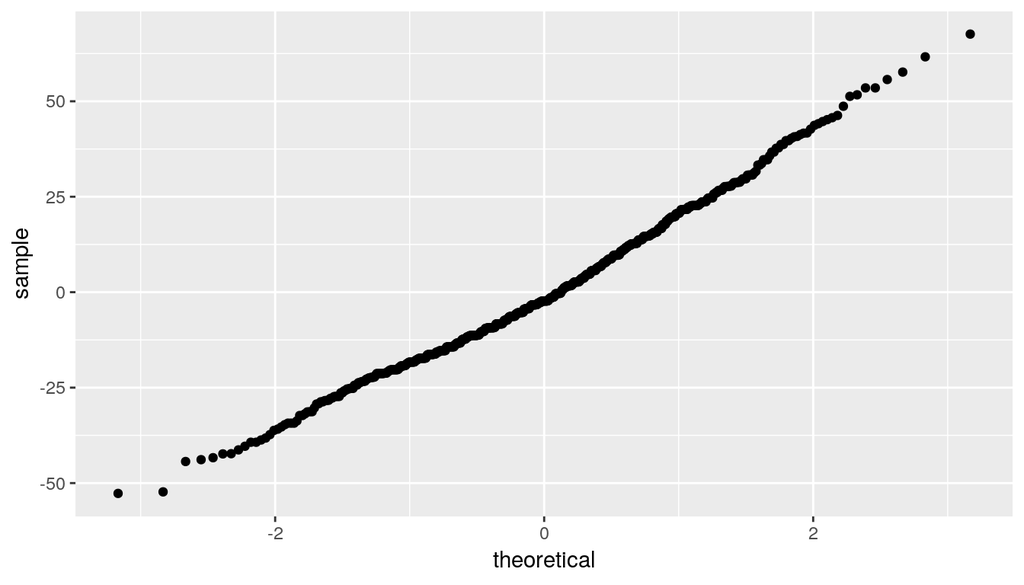

```r
ggplot(data = m4, aes(sample = .resid)) +
  stat_qq()
```

#### Constant variability of residuals

On the other hand, **the variability does not look constant**, which is shown in the plot:

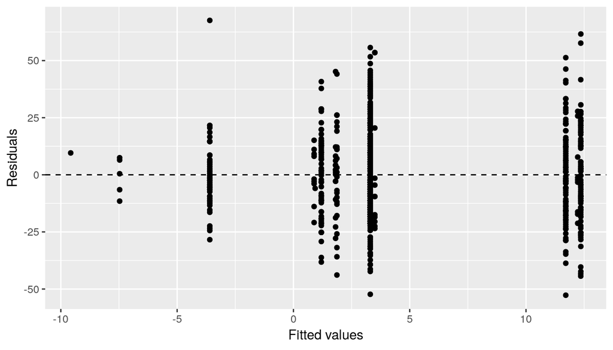

```r
ggplot(data = m4, aes(x = .fitted, y = .resid)) +
  geom_point() +
  geom_hline(yintercept = 0, linetype = "dashed") +
  xlab("Fitted values") +
  ylab("Residuals")
```

The residuals **do not** follow a **constant variability**.

## Part 5: Prediction

We are now going to check how would our model **m4** predict a movie that is not in the data set.

According to Rotten Tomatoes attributes (https://www.rottentomatoes.com/m/moonlight_2016) and Awards information from IMDb (https://www.imdb.com/title/tt4975722/awards), the movie is defined as follows:

- Titlle: Moonlight
- Genre: Drama
- Best Picture: yes
- Audience score on Rotten Tomatoes: 0.79
- Critics score on Rotten Tomatoes: 0.98
- score_diff (audience-critics) = 79-98 = -19

Now we are going to use the data and the model to **predict** the score_diff:

```r
moonlight <- data.frame(genre="Drama", best_pic_win="yes")
predict(m4, moonlight, interval = "confidence") #default 95%
```

```
##         fit      lwr      upr
## 1 -7.471516 -22.1558 7.212765
```

## Part 6: Conclusion

Another consideration would be on the **use of categorical** variables: variables that does not have many samples for each value, like the **director**, are bad for building models. To handle this issue, perhaps a bigger sample size could help. In my opinion, to be more accurate, other variables from movies should be considered, which are not in the database. In **future work**, we could interconnect databases with more attributes from each movie. Other attributes also could be simplified, such as the presence of the most famous **artists**, **directors**, etc. Again, a bigger sample size would be necessary, once they are all categorical attributes which are converted in **thousands of dummy** variables, **requiring the number of samples to be even bigger**. Also, the adjusted $R^2$ decreases the bigger is the number of variables.

Now revisiting the Research Question:

> Is there an overwall difference between audicence and critics’ opinions? Could the differences that happens in each movie be explained by variables related to Genre, Director, Best Picture and best Actor/Actress Oscars?

We conclude that there is a significant difference between audience and critics’ opinions, since the difference between the percentages of high rates from each group exist and is statistically significant (paired t-test, p < 0.05). **On the other hand**, despite the significant relationships found by the model (p <0.05), the variables and our models could not explain the differences, once the **$R^2$** and the adjusted $R^2$ were very low.

This means that this “model explains the data significantly better than would just looking at the average value of the dependent variable”, our score_diff. “This often happens when there is a lot of variability in the dependent variable, but there are enough data points for a significant relationship to be indicated” (reference: http://rcompanion.org/handbook/G_10.html).